# Assignment 2

Name : Ibtesam Shaikh

Student ID: 100812266

**Assignment 2:**  
**Linear Regression**

**TO-DO:**

1. Using Python develop a **Multivariate/Multiple Regression Algorithm** script to predict CMS (Concrete compressive strength).  
   **Note: All steps need to be annotated (i.e. header notes for each step)**
2. Summary of key findings based on your Python Script:  
   a. State and Explain the Key Statistics of the Dataset (i.e. Mean, Std Deviation, etc.)  
   b. State and Explain the Regression Model Algorithm  
   c. Evaluate the Algorithm (i.e. Do you think it’s a good model? Why/Why Not?)
3. Next Steps  
   a. Identify three (3) ways to help improve the performance of the model? Please justify each of your answers.

**Dataset:**

The variables are as follows:  
**Independent Variables:**  
• Cement - kg in a m3 mixture  
• Blast - Blast Furnace Slag (kg in a m3 mixture)  
• Fly Ash – Fly Ash (kg in a m3 mixture)  
• Water - Water (kg in a m3 mixture)  
• Superplasticizer – Superplasticizer (kg in a m3 mixture)  
• CA - Coarse Aggregate (kg in a m3 mixture)  
• FA - Fine Aggregate (kg in a m3 mixture)  
• Age - Day (1~365)  
**Dependent Variable:**  
• CMS - Concrete compressive strength

**Theory:**

**• Regression:**

1.Regression is a Method of Finding a Relationship between a Independent Variable and Dependent Variable.  
2.In Regression Model, the Dependent Variable is a Continuous Variable.  
3.The dependent Variable is known as a Target.  
4.The Independent Variables are called Features.  
5.The dependent Variable relationship with respect to the Independent Variable is predicted.

**• Single Linear Regression:**

1.In Single Linear Regression Model, there is only one Independent Variable and one dependent Variable.

**• Multivariate Regression Model:**

1.There are Multiple Independent Variables and a Single Dependent Variable.

**Linear Regression Modelling:**

1.Linear Regression is based on a very simple formula.  
2.Linear Regression is the basic technique to predict the value of an attribute.  
3.The below snippet Explains the Linear Regression Model:

[figure not shown]

• In Linear Regression Machine Learning Model, the objective is to Obtain the above Equation.

Where,  
1.**y** is the Response/Target or Simply known as Dependent Variable.  
2.**x** is the feature/predictor variable or simply known as independent Variable.  
3.**β0** is the Intercept, the intercept defines the minimum value of Y when x=0. Meaning it is the constant value and its not dependable on x.  
4.**β1** is the co-efficient of the independent variable.

β1 is also the slope of the Linear regression line.

[figure not shown]

• In Linear regression Model, the Model achieves a Linear regression line which is also known as a best fit line.  
• In the above snippet of plotted X and Y points, the Actual points and Linear regression line is plotted. The snippet says if the points were lying on the line or near it to it the model is said to be best fit or has good performance.  
• If the points are further away from the point, we calculate the “u” , the residual or error which is the difference between the Actual Point and predicted point on the Line.  
In a Multivariate Regression Model:  
• We have one dependent variable (y) and we have 2 or More independent Variable (xn). • In Multivariate Regression Model the equation obtained will be:

```
       y=β0  + β1x1 +β2x2 +………+ βnxn
```

Where ,  
1.**y** is the Response/Target or Simply known as Dependent Variable.  
2.**xn** is the feature/predictor variable or simply known as independent Variable and n determines the number of independent variables.  
3.**β0** is the Intercept, the intercept defines the minimum value of Y when x=0. Meaning it is the constant value and it’s not dependable on x.  
4.**βn** is the co-efficient of the independent variable and n determines the number of Co-efficient.

**Regression of Sum of Squares:**

[figure not shown]

The regression sum of squares describes how well a regression model represents the modeled data.

**Error of Sum of Squares:**

[figure not shown]

SSE is the sum of the squared differences between each observation and its group's mean.

Smaller the value of SSR or SSE, the more accurate the prediction will be, which would make the model the best fit.

**Modelling:**

Import the packages

```python
import numpy as np
import pandas as pd
import matplotlib.pyplot as plt
%matplotlib inline
import seaborn as sns
```

Read the CSV File

```python
Data=pd.read_csv("Concrete_Data.csv")
```

**The first 5 records and the last 5 records.**

Head function reads the first 5 Records

```python
Data.head()
```

|  | Cement | Blast | Fly Ash | Water | Superplasticizer | CA | FA | Age | CMS |
| --- | --- | --- | --- | --- | --- | --- | --- | --- | --- |
| 0 | 540.0 | 0.0 | 0.0 | 162.0 | 2.5 | 1040.0 | 676.0 | 28 | 79.99 |
| 1 | 540.0 | 0.0 | 0.0 | 162.0 | 2.5 | 1055.0 | 676.0 | 28 | 61.89 |
| 2 | 332.5 | 142.5 | 0.0 | 228.0 | 0.0 | 932.0 | 594.0 | 270 | 40.27 |
| 3 | 332.5 | 142.5 | 0.0 | 228.0 | 0.0 | 932.0 | 594.0 | 365 | 41.05 |
| 4 | 198.6 | 132.4 | 0.0 | 192.0 | 0.0 | 978.4 | 825.5 | 360 | 44.30 |

Tail function reads last 5 records.

```python
Data.tail()
```

|  | Cement | Blast | Fly Ash | Water | Superplasticizer | CA | FA | Age | CMS |
| --- | --- | --- | --- | --- | --- | --- | --- | --- | --- |
| 1025 | 276.4 | 116.0 | 90.3 | 179.6 | 8.9 | 870.1 | 768.3 | 28 | 44.28 |
| 1026 | 322.2 | 0.0 | 115.6 | 196.0 | 10.4 | 817.9 | 813.4 | 28 | 31.18 |
| 1027 | 148.5 | 139.4 | 108.6 | 192.7 | 6.1 | 892.4 | 780.0 | 28 | 23.70 |
| 1028 | 159.1 | 186.7 | 0.0 | 175.6 | 11.3 | 989.6 | 788.9 | 28 | 32.77 |
| 1029 | 260.9 | 100.5 | 78.3 | 200.6 | 8.6 | 864.5 | 761.5 | 28 | 32.40 |

**Key Stastistics:**

The describe() function gives all the stastical inputs- Count, Mean, Standrad deviation, Boxplot Attributes for every Column in the Table.

```python
Data.describe()
```

|  | Cement | Blast | Fly Ash | Water | Superplasticizer | CA | FA | Age | CMS |
| --- | --- | --- | --- | --- | --- | --- | --- | --- | --- |
| count | 1030.000000 | 1030.000000 | 1030.000000 | 1030.000000 | 1030.000000 | 1030.000000 | 1030.000000 | 1030.000000 | 1030.000000 |
| mean | 281.167864 | 73.895825 | 54.188350 | 181.567282 | 6.204660 | 972.918932 | 773.580485 | 45.662136 | 35.817961 |
| std | 104.506364 | 86.279342 | 63.997004 | 21.354219 | 5.973841 | 77.753954 | 80.175980 | 63.169912 | 16.705742 |
| min | 102.000000 | 0.000000 | 0.000000 | 121.800000 | 0.000000 | 801.000000 | 594.000000 | 1.000000 | 2.330000 |
| 25% | 192.375000 | 0.000000 | 0.000000 | 164.900000 | 0.000000 | 932.000000 | 730.950000 | 7.000000 | 23.710000 |
| 50% | 272.900000 | 22.000000 | 0.000000 | 185.000000 | 6.400000 | 968.000000 | 779.500000 | 28.000000 | 34.445000 |
| 75% | 350.000000 | 142.950000 | 118.300000 | 192.000000 | 10.200000 | 1029.400000 | 824.000000 | 56.000000 | 46.135000 |
| max | 540.000000 | 359.400000 | 200.100000 | 247.000000 | 32.200000 | 1145.000000 | 992.600000 | 365.000000 | 82.600000 |

**Check if the Data is Normally Distributed :**

**.plot.kde** displays if the data is Normally distirbuted.

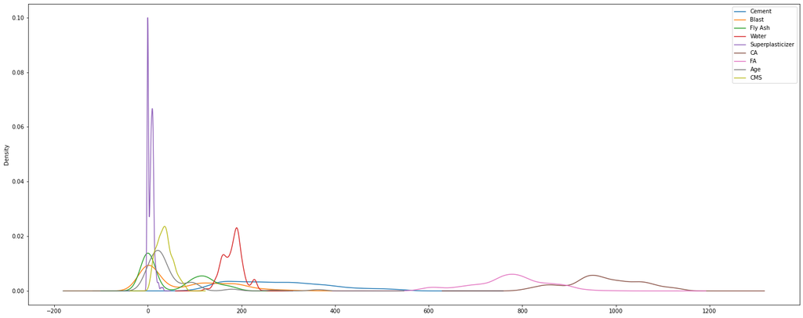

```python
Data.plot.kde(figsize=(25,10))
```

The dataset is not Normally Distributed  
The Data is mostly Right skewed or postively skewed.

**Boxplot Visulization:**

Boxplot Visualization predicts the Outliers in the given Dataset.

The **plt.figure()** is derived from the **Matplotlib.pyplot** library. Which defines the size of the boxplot. If the Size isn't defined the Boxplot would look compressed.

The **sns.boxplot()** is derived form the **seaborn** library and data=Data refers to the "Data" dataset.It generates boxplot for "Data" Dataset.

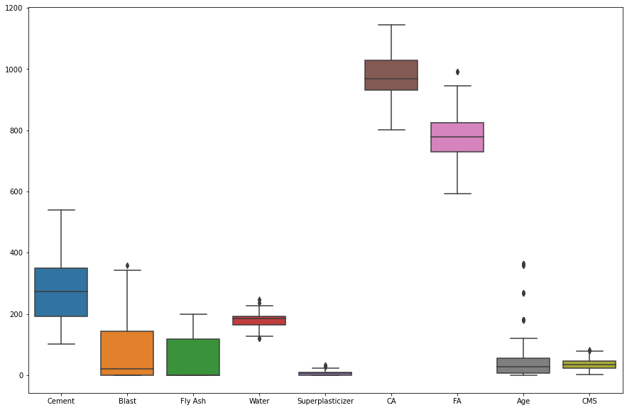

```python
plt.figure(figsize=(15,10))
sns.boxplot(data=Data)
```

From the above Boxplot, The small dotted circles are the Outliers.

Outliers are present in the Varaibles - Blast ,Water,SuperPlasticizer,FA,Age and CMS

Variable Age and Water have the most Outliers

**Correlation Heatmap**

**.heatmap()** is a function from seabron which diplays a heatmap.

**.corr()**determines the correlation in the dataset.

**annot=TRUE** displays the correlation values.

orange is high positvely correlated and black is high negatively correlated

The Correlation goes from + to - from orange to black.

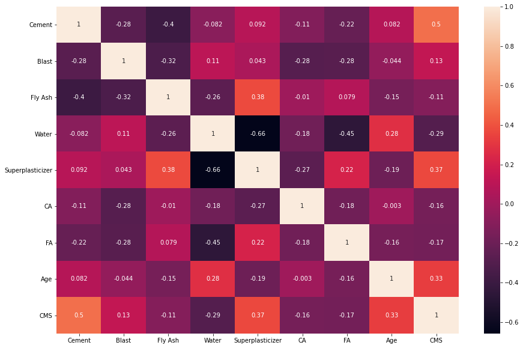

```python
plt.figure(figsize=(15,10))
sns.heatmap(Data.corr(),annot=True)
```

Multivaraite Regression Model

We Know the the Equation : **y=mx+c** is the Eqaution needs to be generated for a Linear Regression Model for one independent and dependent Varaible

Where m is the coefficient,c is the intercept,y is the dependent Variable and X is the Independent Variable

For a MultiVariate Regression, we have multiple Independent variables and one Dependent Variable .

Therefore, the Number of coefficients will be more depending on the independent Variables

Therefore for the given Business Model.

```python
Data.columns
```

```
Index(['Cement', 'Blast', 'Fly Ash', 'Water', 'Superplasticizer', 'CA', 'FA',
       'Age', 'CMS'],
      dtype='object')
```

**Data.columns()** gives you all the Varaibles of the dataset

**Variables**- Cement, Blast, Fly Ash, Water, Superplasticizer, CA , FA and Age are the inddependent Variables or Features

**Variable**- CMS is the dependent Variable/Target

Therefore, **the Multivariate Regression Model** Equation will be :

**y = a(x1) + b(x2) + c(x3) + d(x4) + e(x5) + f(x6) + g(x7) + h(x8) + c**

Where,

y=CMS

x1=Cement

x2=Blast

x3=Fly Ash

x4=Water

x5=Superplasticizer

x6=CA

x7=FA

x8=Age

a,b,c,d,e,f,g,h,i are the Coefficients

c is the intercept

**TASK:** To Establish the relationship between Dependent Variable and Independent Variable.

**Step 1:**Create X and Y Variables

**drop()** drops the CMS Column from the dataset and assigns all other variables to x. axis=1 Specifies column.

y is assigned CMS Varaible .

x is the Independent Variable and y is the dependent variable.

**.to_numpy()** stores the data to an array

```python
x = Data.drop('CMS',axis=1).to_numpy()
y = Data['CMS'].to_numpy()
```

**Step 2:** Creating Train and Test Data

**skilearn.model_selection** is the package from which **train_test_split** function is imported.

**test_size** determines the size of the test data set.we are considering 80:20 ratio

**random_state** number splits the train and test datasets with random manner.

```python
from sklearn.model_selection import train_test_split
x_train,x_test,y_train,y_test=train_test_split(x,y,test_size=0.2,random_state=100)
```

**Step 3:**Standardization of the Data.

Standardization of the Data is one of the most important step.Standardization comes into picture when features of input data set have large differences between their ranges, or simply when they are measured in different measurement units (e.g., Pounds, Meters, Miles … etc).It is one of the pre-processing step.

StandardScaler is the function used to Standardize the data.It is imported from **sklearn.preprocessing** package.

**fit_transform** is used on the training data. The **fit** method is calculating the mean and variance of each of the features present in our data. The **transform** method is transforming all the features using the respective mean and variance and transforms the data in one format.

**transform** is used on the testng data.Using the **transform** method we can use the same mean and variance as it is calculated from our training data to transform our test data.

```python
from sklearn.preprocessing import StandardScaler
sc = StandardScaler()
x_train2 = sc.fit_transform(x_train)
x_test2 = sc.transform(x_test)
```

**Step 4:**Import the packages and Libraries needed to Model Linear Regression and Intercepts,Coefficients.

Import **LinearRegression** and **metrics** package to calculate the R2, intercept.

```python
from sklearn.linear_model import LinearRegression
from sklearn import metrics
from sklearn.metrics import r2_score
```

**Step 5:**Lets Model the Linear Regression Model.

**Method** is assigned **LinearRegression()** Model.

**n_jobs** Number of jobs used for Computation.

**Method.fit** fits the training data in the Linear Regression Model.

**Method.predict** prdicts the y in the test dataset based on train dataset predictions.

**Method.intercept_** determines the intercept_

**{:0.2f}** displays the rounded float values to its first 2 decimals.

**Method.coef_** determines the coefficient of the Variables.

```python
Method=LinearRegression(n_jobs=1)
Method.fit(x_train2,y_train)
predict=Method.predict(x_test2)
print("Method:Linear Regression")
print("\nIntercept: {:0.2f}".format(float(Method.intercept_)))
coeff=Method.coef_
print("\n")
print("Coefficients:\n")
coeff1=pd.Series(['Cement','Blast','Fly Ash','Water','Superplasticizer','CA','FA','Age'],index=[coeff])
coeff1
```

```
Method:Linear Regression

Intercept: 35.95


Coefficients:
```

```
 13.027382              Cement
 8.952089                Blast
 5.955866              Fly Ash
-2.849777                Water
 1.737942     Superplasticizer
 1.592146                   CA
 2.035610                   FA
 7.219311                  Age
dtype: object
```

Therefore, the Multivariate Regression Equation is :

**y = 13.02(x1) + 8.95(x2) + 5.95(x3) - 2.84(x4) + 1.73(x5) + 1.59(x6) + 2.03(x7) + 7.2(x8) + 35.95**

**Step 6**: Calculate the Accuracy :

R2

Mean Absolute Error

Mean Squared Error

Root Mean Squared Error

```python
r2=r2_score(y_test,predict)
print("R2 Value:")
print(r2)
print("\n")
MAE=metrics.mean_absolute_error(y_test, predict)
print("Mean Absolute Error:")
print(MAE)
print("\n")
MSE=metrics.mean_squared_error(y_test, predict)
print('Mean Squared Error:')
print(MSE)
print("\n")
RMSE=np.sqrt(MSE)
print("Root Mean Squared Error:")
print(RMSE)
```

```
R2 Value:
0.6225200877404842


Mean Absolute Error:
8.262654160599254


Mean Squared Error:
113.17875937789906


Root Mean Squared Error:
10.63855062392895
```

The R2 Value is not that great

The Model is a Moderate fit Model.

The model can be Improved

**Forecast Table:** Compares the Actual Y and predicted Y values and the difference.

```python
predict2 = predict.T
diff = predict2-y_test
FcstTble=pd.DataFrame({'Actual':y_test,'Predicted':predict2.round(2),'Difference':diff.round(2)})
print('\nForecast Table')
FcstTble.head()
```

```
Forecast Table
```

|  | Actual | Predicted | Difference |
| --- | --- | --- | --- |
| 0 | 68.10 | 61.14 | -6.96 |
| 1 | 71.30 | 53.63 | -17.67 |
| 2 | 25.18 | 22.28 | -2.90 |
| 3 | 19.52 | 27.85 | 8.33 |
| 4 | 38.02 | 51.58 | 13.56 |

**The Ways to Improve the Performace of the Model:**

**Outliers:**

There were Quiet a few Outliers in the Dataset. The Outliers need to be removed for the better performance of the Model.  
1.Remove the Outliers.  
**OR**  
2Replace the outlier by the highest value  
**OR**  
3.Replace the outliers by the mean value

**Dimensionality Reduction:**

Dimension reduction, is the transformation of data from a high-dimensional space into a low-dimensional space so that the low-dimensional representation retains some meaningful properties of the original data, ideally close to its intrinsic dimension. Two Methods to perfrom Dimension Reduction:

1. Principal Component Analysis.  
   **OR**
2. Linear Discrimant Analysis.

**Larger Dataset And Normal Distributed Data:**

1.Conisder a Larger Dataset, to have a better Variation and less chance of Error.  
2.Make Sure the Data is a Normally Distributed. That means mean , median and mode are same or nearly same and standarad distribution is 1.

**Performance Improvement :**

Lets try to improvise the Model by treating the Outliers and Making the Data Normally distributed and check if there is an Improvement in the data.

Step 1:Detect Outliers

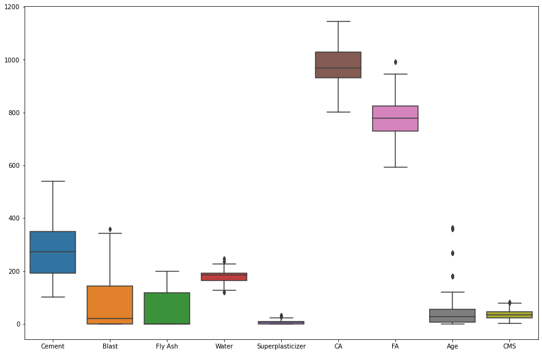

```python
plt.figure(figsize=(15,10))
sns.boxplot(data=Data)
```

Step 2:Remove the Outliers

**Data.quantile** Calculates the 25th and 75th percentile.

```
Cement              -44.0625
Blast              -214.4250
Fly Ash            -177.4500
Water               124.2500
Superplasticizer    -15.3000
CA                  785.9000
FA                  591.3750
Age                 -66.5000
CMS                  -9.9275
dtype: float64 Cement               586.4375
Blast                357.3750
Fly Ash              295.7500
Water                232.6500
Superplasticizer      25.5000
CA                  1175.5000
FA                   963.5750
Age                  129.5000
CMS                   79.7725
dtype: float64
```

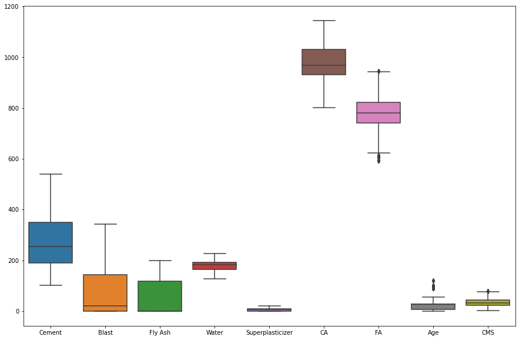

```python
Q1=Data.quantile(0.25)
Q3=Data.quantile(0.75)
IQR=Q3-Q1
lowqe_bound=Q1 - 1.5 * IQR
upper_bound=Q3 + 1.5 * IQR
print(lowqe_bound,upper_bound)
df =Data[~((Data < lowqe_bound) |(Data > upper_bound)).any(axis=1)]
plt.figure(figsize=(15,10))
sns.boxplot(data=df)
```

Most of the Outliers have been removed, Lets repeat the process to eliminate the rest.

```
Cement              -47.750
Blast              -217.500
Fly Ash            -177.450
Water               124.250
Superplasticizer    -15.450
CA                  783.500
FA                  619.200
Age                 -24.500
CMS                 -10.385
dtype: float64 Cement               587.050
Blast                362.500
Fly Ash              295.750
Water                232.650
Superplasticizer      25.750
CA                  1179.500
FA                   944.000
Age                   59.500
CMS                   77.655
dtype: float64
```

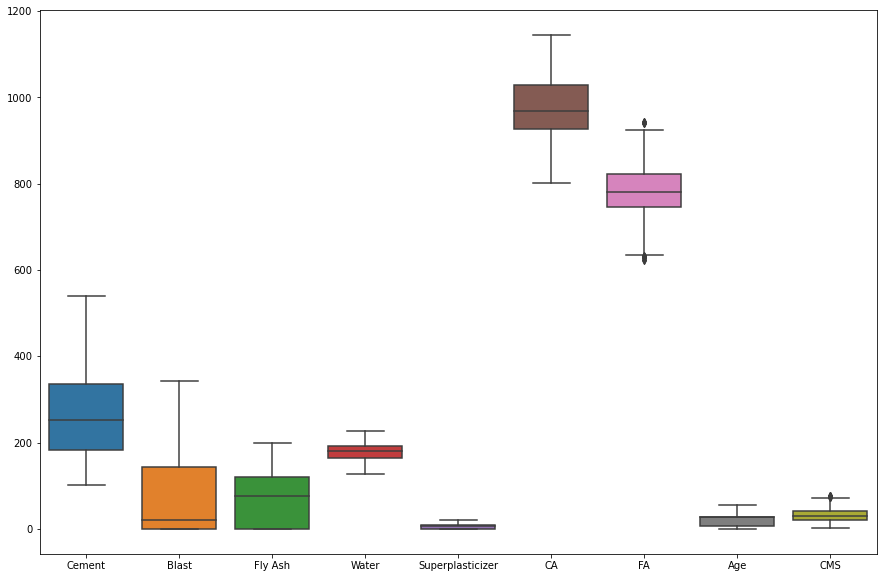

```python
Q1=df.quantile(0.25)
Q3=df.quantile(0.75)
IQR=Q3-Q1
lowqe_bound=Q1 - 1.5 * IQR
upper_bound=Q3 + 1.5 * IQR
print(lowqe_bound,upper_bound)
df1 =df[~((df < lowqe_bound) |(df > upper_bound)).any(axis=1)]
plt.figure(figsize=(15,10))
sns.boxplot(data=df1)
```

There are outliers in FA and CMS, Lets repeat the process to eliminate the rest.

```
Cement              -46.05
Blast              -217.50
Fly Ash            -182.40
Water               124.25
Superplasticizer    -15.60
CA                  775.90
FA                  633.35
Age                 -24.50
CMS                 -11.25
dtype: float64 Cement               567.15
Blast                362.50
Fly Ash              304.00
Water                232.65
Superplasticizer      26.00
CA                  1179.90
FA                   935.35
Age                   59.50
CMS                   73.43
dtype: float64
```

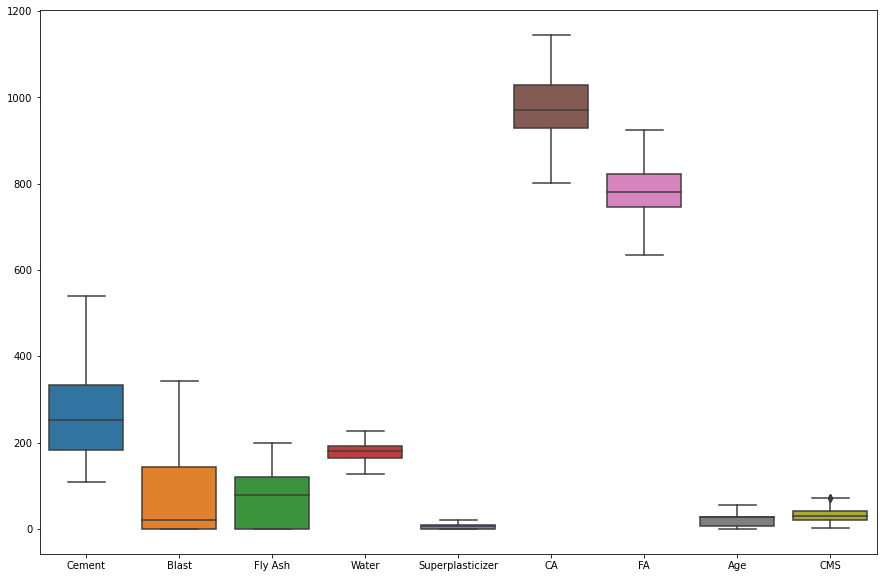

```python
Q1=df1.quantile(0.25)
Q3=df1.quantile(0.75)
IQR=Q3-Q1
lowqe_bound=Q1 - 1.5 * IQR
upper_bound=Q3 + 1.5 * IQR
print(lowqe_bound,upper_bound)
df2 =df1[~((df < lowqe_bound) |(df > upper_bound)).any(axis=1)]
plt.figure(figsize=(15,10))
sns.boxplot(data=df2)
```

All the Outliers have been Removed.There is very small one in the CMS, Which can be neglected as its very close the 75th percentile.

Step 3:To check if the Data is Normally Distributed.

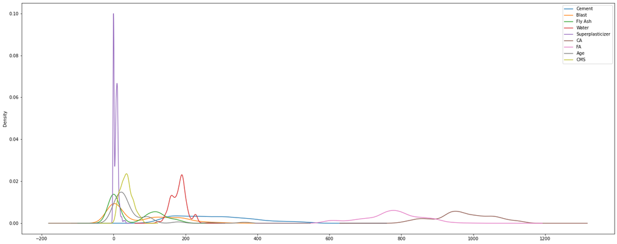

```python
Data.plot.kde(figsize=(25,10))
```

1.The Data is not Normally Distributed.</br> 2.The Data is highly positive skewed.

**MinMaxScaler**

- One of the most popular- Used for Normalizing the data.
- Calculate - Subtract min of column & div by difference between max & min

[figure not shown]

- Data shifts between 0 & 1
- If distribution not suitable for StandardScaler i.e when the data is not normally distributed, this scaler works out.
- Sensitive to outliers

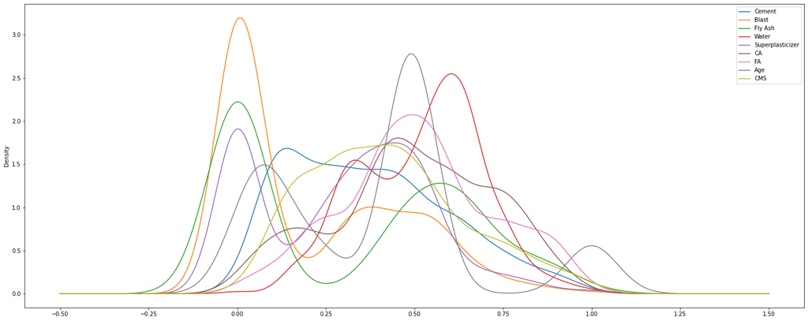

```python
from sklearn.preprocessing import MinMaxScaler
Mn = MinMaxScaler()
data_tf = Mn.fit_transform(df2)
df_a = pd.DataFrame(data_tf,columns=['Cement','Blast','Fly Ash','Water','Superplasticizer','CA','FA','Age','CMS'])
df_a.plot.kde(figsize=(25,10))
```

The data is more alligned towards the center

The Data is not completly normally Distributed.

Step 4:Modelling:

All the Packages and Variables are assigned above.

```python
x = df2.drop('CMS',axis=1).to_numpy()
y = df2['CMS'].to_numpy()

x_train,x_test,y_train,y_test=train_test_split(x,y,test_size=0.2,random_state=100)

sc = StandardScaler()
x_train2 = sc.fit_transform(x_train)
x_test2 = sc.transform(x_test)


Method.fit(x_train2,y_train)
predict=Method.predict(x_test2)
print("Method:Linear Regression")
print("\nIntercept: {:0.2f}".format(float(Method.intercept_)))
coeff=Method.coef_
print("\n")
print("Coefficients:\n")
coeff1=pd.Series(['Cement','Blast','Fly Ash','Water','Superplasticizer','CA','FA','Age'],index=[coeff])
coeff1
```

```
Method:Linear Regression

Intercept: 32.35


Coefficients:
```

```
 9.907428              Cement
 6.315157               Blast
 2.207817             Fly Ash
-4.055979               Water
 0.540026    Superplasticizer
-0.437982                  CA
-0.076069                  FA
 8.405151                 Age
dtype: object
```

Therefore, the Multivariate Regression Equation is :

**y = 9.90(x1) + 6.31(x2) + 2.20(x3) - 4.05(x4) + 0.5(x5) - 0.43(x6) - 0.07(x7) + 8.4(x8) + 32.35**

Step 5:Calculate the Accuracy :

```python
r2=r2_score(y_test,predict)
print("R2 Value:")
print(r2)
print("\n")
MAE=metrics.mean_absolute_error(y_test, predict)
print("Mean Absolute Error:")
print(MAE)
print("\n")
MSE=metrics.mean_squared_error(y_test, predict)
print('Mean Squared Error:')
print(MSE)
print("\n")
RMSE=np.sqrt(MSE)
print("Root Mean Squared Error:")
print(RMSE)
```

```
R2 Value:
0.8468468589213872


Mean Absolute Error:
4.638833023015542


Mean Squared Error:
36.87872394562736


Root Mean Squared Error:
6.07278551783507
```

**Conclusion:**

The Model was a Moderate performing Model with R^2 of 0.622.

There is a Significant Increase in the R^2 and the performance. The R^2 is 0.84 Which is a good Model.

Considering the Dimension Reduction Methods, the performance can be still increased.